# I. Introduction

We are Group 1. Our chosen topic is: Forecasting US Interest Rate.

# II. Data Acquisition

Base on the raw "US FRED_MD Macro Dataset.xlsx" file, we convert the "US FRED-MD Macro Data" sheet to csv; Same for "Definition_Transformation Code" sheet.

# III. Data Preparation

Next, base on this "US FRED-MD Macro Data" csv, we perform the following steps for i. Data Exploration and ii. Data Preprocessing with "Definition_Transformation Code" csv to obtain the "cleaned_US FRED-MD Macro Dataset.csv" file for IV. Machine Learning part.

```python
# Standard libraries
import pandas as pd
import seaborn as sns
import numpy as np
import matplotlib.pyplot as plt
from numpy import asarray
import os
from statsmodels.stats.outliers_influence import variance_inflation_factor
import time
```

## i. Data Exploration

```python
raw = pd.read_csv('US FRED-MD Macro Dataset.csv', header=0, index_col=0, parse_dates=True)
raw
```

| sasdate | RPI | W875RX1 | DPCERA3M086SBEA | CMRMTSPLx | RETAILx | INDPRO | IPFPNSS | IPFINAL | IPCONGD | IPDCONGD | ... | DNDGRG3M086SBEA | DSERRG3M086SBEA | CES0600000008 | CES2000000008 | CES3000000008 | UMCSENTx | DTCOLNVHFNM | DTCTHFNM | INVEST | VIXCLSx |
| --- | --- | --- | --- | --- | --- | --- | --- | --- | --- | --- | --- | --- | --- | --- | --- | --- | --- | --- | --- | --- | --- |
| 1959-01-01 | 2442.158 | 2293.2 | 17.272 | 2.922664e+05 | 18235.77392 | 21.9665 | 23.3891 | 22.2688 | 31.7011 | 19.0149 | ... | 17.791 | 11.326 | 2.13 | 2.45 | 2.04 | NaN | 6476.00 | 12298.00 | 84.2043 | NaN |
| 1959-02-01 | 2451.778 | 2301.5 | 17.452 | 2.944247e+05 | 18369.56308 | 22.3966 | 23.7048 | 22.4617 | 31.9337 | 19.1147 | ... | 17.798 | 11.343 | 2.14 | 2.46 | 2.05 | NaN | 6476.00 | 12298.00 | 83.5280 | NaN |
| 1959-03-01 | 2467.594 | 2318.5 | 17.617 | 2.934187e+05 | 18523.05762 | 22.7193 | 23.8483 | 22.5719 | 31.9337 | 19.4890 | ... | 17.785 | 11.363 | 2.15 | 2.45 | 2.07 | NaN | 6508.00 | 12349.00 | 81.6405 | NaN |
| 1959-04-01 | 2483.671 | 2334.9 | 17.553 | 2.993228e+05 | 18534.46600 | 23.2032 | 24.1927 | 22.9026 | 32.4374 | 19.6138 | ... | 17.796 | 11.403 | 2.16 | 2.47 | 2.08 | NaN | 6620.00 | 12484.00 | 81.8099 | NaN |
| 1959-05-01 | 2498.026 | 2350.4 | 17.765 | 3.013643e+05 | 18679.66354 | 23.5528 | 24.3936 | 23.1231 | 32.5925 | 20.0130 | ... | 17.777 | 11.421 | 2.17 | 2.48 | 2.08 | 95.3 | 6753.00 | 12646.00 | 80.7315 | NaN |
| ... | ... | ... | ... | ... | ... | ... | ... | ... | ... | ... | ... | ... | ... | ... | ... | ... | ... | ... | ... | ... | ... |
| 2023-01-01 | 17821.000 | 14623.3 | 130.028 | 1.581882e+06 | 692501.00000 | 102.5080 | 101.2863 | 101.3295 | 102.0755 | 104.8646 | ... | 114.885 | 134.903 | 28.91 | 33.44 | 25.82 | 64.9 | 383384.74 | 720635.04 | 5505.6964 | 20.2269 |
| 2023-02-01 | 17839.528 | 14622.7 | 129.991 | 1.575290e+06 | 687942.00000 | 102.5023 | 101.0873 | 101.1983 | 102.1753 | 105.0877 | ... | 115.279 | 135.397 | 28.98 | 33.61 | 25.81 | 67.0 | 385165.01 | 718917.35 | 5491.3981 | 20.2141 |
| 2023-03-01 | 17885.887 | 14664.3 | 129.948 | 1.560472e+06 | 681673.00000 | 102.6521 | 101.0102 | 101.1678 | 102.4580 | 103.9786 | ... | 114.930 | 135.782 | 29.12 | 33.79 | 25.95 | 62.0 | 388912.72 | 719670.11 | 5366.2449 | 22.0446 |
| 2023-04-01 | 17866.773 | 14659.0 | 130.255 | 1.556928e+06 | 684213.00000 | 103.1748 | 101.7373 | 102.1572 | 103.4504 | 108.3743 | ... | 115.341 | 136.315 | 29.22 | 33.92 | 26.03 | 63.5 | 390133.21 | 720155.25 | 5250.7099 | 17.4930 |
| 2023-05-01 | 17915.688 | 14702.7 | 130.222 | NaN | 686573.00000 | 103.0107 | 101.6856 | 102.0669 | 103.3327 | 108.7279 | ... | 114.944 | 136.665 | 29.36 | 34.07 | 26.19 | 59.2 | NaN | NaN | 5220.8945 | 17.3964 |

773 rows × 127 columns

```python
raw.describe()
```

|  | RPI | W875RX1 | DPCERA3M086SBEA | CMRMTSPLx | RETAILx | INDPRO | IPFPNSS | IPFINAL | IPCONGD | IPDCONGD | ... | DNDGRG3M086SBEA | DSERRG3M086SBEA | CES0600000008 | CES2000000008 | CES3000000008 | UMCSENTx | DTCOLNVHFNM | DTCTHFNM | INVEST | VIXCLSx |
| --- | --- | --- | --- | --- | --- | --- | --- | --- | --- | --- | --- | --- | --- | --- | --- | --- | --- | --- | --- | --- | --- |
| count | 773.000000 | 773.000000 | 773.000000 | 7.720000e+02 | 773.000000 | 773.000000 | 773.000000 | 773.000000 | 773.000000 | 773.000000 | ... | 773.000000 | 773.000000 | 773.000000 | 773.000000 | 773.000000 | 619.000000 | 772.000000 | 772.000000 | 773.000000 | 731.000000 |
| mean | 8832.032693 | 7545.187451 | 62.543856 | 8.537374e+05 | 211666.926536 | 66.826535 | 71.223933 | 69.987593 | 78.680652 | 65.903962 | ... | 60.156718 | 58.161638 | 12.304735 | 14.290155 | 11.369457 | 85.583360 | 126984.951801 | 335154.032409 | 1243.612069 | 19.400722 |
| std | 4613.095755 | 3670.604388 | 33.163356 | 3.968282e+05 | 176317.019307 | 26.600038 | 27.137274 | 27.397822 | 23.411854 | 28.352248 | ... | 29.405628 | 36.614499 | 7.561949 | 8.463133 | 6.826475 | 12.949166 | 123252.349886 | 322899.123410 | 1376.607743 | 7.118632 |
| min | 2442.158000 | 2293.200000 | 17.272000 | 2.809324e+05 | 18235.773920 | 21.966500 | 23.389100 | 22.268800 | 31.701100 | 17.392900 | ... | 17.777000 | 11.326000 | 2.130000 | 2.450000 | 2.040000 | 50.000000 | 6476.000000 | 12298.000000 | 71.186400 | 9.484400 |
| 25% | 4823.641000 | 4291.000000 | 32.507000 | 5.129268e+05 | 48463.827530 | 44.584800 | 46.877800 | 44.693100 | 61.160700 | 41.759800 | ... | 31.522000 | 20.988000 | 4.980000 | 6.590000 | 4.580000 | 76.000000 | 10744.250000 | 33756.000000 | 172.216500 | 14.334650 |
| 50% | 7789.786000 | 6800.300000 | 54.668000 | 7.548073e+05 | 161003.329500 | 62.178900 | 70.920700 | 69.209400 | 80.278400 | 60.013000 | ... | 64.962000 | 56.218000 | 11.660000 | 13.630000 | 11.000000 | 89.300000 | 78250.500000 | 187087.545000 | 640.140600 | 17.669500 |
| 75% | 12831.880000 | 10740.600000 | 95.065000 | 1.221233e+06 | 347405.000000 | 93.632800 | 98.986300 | 97.992600 | 100.259700 | 95.553100 | ... | 86.296000 | 90.206000 | 18.570000 | 20.780000 | 17.200000 | 94.950000 | 262396.542500 | 724682.920000 | 2021.722900 | 22.588350 |
| max | 21448.063000 | 14702.700000 | 130.255000 | 1.585920e+06 | 692501.000000 | 104.118100 | 110.221900 | 108.677700 | 111.785000 | 110.128800 | ... | 115.940000 | 136.665000 | 29.360000 | 34.070000 | 26.190000 | 112.000000 | 390133.210000 | 896985.060000 | 5836.411700 | 62.964800 |

8 rows × 127 columns

As we observe, this is a time series data, starting from 1959-01-01 to 2023-05-01, with month as the interval, and 127 features that represent the Macroeconomic and the financial market time series data. Our target is to forecast the US Interest Rate (FEDFUNDS).

### A. Missing Value Handling

```python
# Check the quality of data -- Missing value
missing_values = np.sum(pd.isna(raw))

for column, count in missing_values.items():
    print(f"{column}: {count}")
```

```
RPI: 0
W875RX1: 0
DPCERA3M086SBEA: 0
CMRMTSPLx: 1
RETAILx: 0
INDPRO: 0
IPFPNSS: 0
IPFINAL: 0
IPCONGD: 0
IPDCONGD: 0
IPNCONGD: 0
IPBUSEQ: 0
IPMAT: 0
IPDMAT: 0
IPNMAT: 0
IPMANSICS: 0
IPB51222S: 0
IPFUELS: 0
CUMFNS: 0
HWI: 1
HWIURATIO: 1
CLF16OV: 0
CE16OV: 0
UNRATE: 0
UEMPMEAN: 0
UEMPLT5: 0
UEMP5TO14: 0
UEMP15OV: 0
UEMP15T26: 0
UEMP27OV: 0
CLAIMSx: 0
PAYEMS: 0
USGOOD: 0
CES1021000001: 0
USCONS: 0
MANEMP: 0
DMANEMP: 0
NDMANEMP: 0
SRVPRD: 0
USTPU: 0
```

[output cut: 72 more lines]

```
CPIULFSL: 0
CUSR0000SA0L2: 0
CUSR0000SA0L5: 0
PCEPI: 0
DDURRG3M086SBEA: 0
DNDGRG3M086SBEA: 0
DSERRG3M086SBEA: 0
CES0600000008: 0
CES2000000008: 0
CES3000000008: 0
UMCSENTx: 154
DTCOLNVHFNM: 1
DTCTHFNM: 1
INVEST: 0
VIXCLSx: 42
```

```python
# Show percentage of missing value of each column
columns_with_missing = {}
total_row = len(raw)
for column, count in missing_values.items():
    percentage = (count / total_row) * 100
    print(f"{column}: {percentage}%")
    if count > 0:
        columns_with_missing[column] = percentage
```

```
RPI: 0.0%
W875RX1: 0.0%
DPCERA3M086SBEA: 0.0%
CMRMTSPLx: 0.129366106080207%
RETAILx: 0.0%
INDPRO: 0.0%
IPFPNSS: 0.0%
IPFINAL: 0.0%
IPCONGD: 0.0%
IPDCONGD: 0.0%
IPNCONGD: 0.0%
IPBUSEQ: 0.0%
IPMAT: 0.0%
IPDMAT: 0.0%
IPNMAT: 0.0%
IPMANSICS: 0.0%
IPB51222S: 0.0%
IPFUELS: 0.0%
CUMFNS: 0.0%
HWI: 0.129366106080207%
HWIURATIO: 0.129366106080207%
CLF16OV: 0.0%
CE16OV: 0.0%
UNRATE: 0.0%
UEMPMEAN: 0.0%
UEMPLT5: 0.0%
UEMP5TO14: 0.0%
UEMP15OV: 0.0%
UEMP15T26: 0.0%
UEMP27OV: 0.0%
CLAIMSx: 0.0%
PAYEMS: 0.0%
USGOOD: 0.0%
CES1021000001: 0.0%
USCONS: 0.0%
MANEMP: 0.0%
DMANEMP: 0.0%
NDMANEMP: 0.0%
SRVPRD: 0.0%
USTPU: 0.0%
```

[output cut: 72 more lines]

```
CPIULFSL: 0.0%
CUSR0000SA0L2: 0.0%
CUSR0000SA0L5: 0.0%
PCEPI: 0.0%
DDURRG3M086SBEA: 0.0%
DNDGRG3M086SBEA: 0.0%
DSERRG3M086SBEA: 0.0%
CES0600000008: 0.0%
CES2000000008: 0.0%
CES3000000008: 0.0%
UMCSENTx: 19.922380336351875%
DTCOLNVHFNM: 0.129366106080207%
DTCTHFNM: 0.129366106080207%
INVEST: 0.0%
VIXCLSx: 5.433376455368694%
```

```python
# Get columns with missing values, with their counts and percentage
sorted_columns = sorted(columns_with_missing.items(), key=lambda x: x[1], reverse=True)
for column, percentage in sorted_columns:
    count = missing_values[column]
    print(f"{column}: {count} missing values ({percentage:.2f}%)")
```

```
ACOGNO: 398 missing values (51.49%)
TWEXAFEGSMTHx: 168 missing values (21.73%)
UMCSENTx: 154 missing values (19.92%)
ANDENOx: 109 missing values (14.10%)
VIXCLSx: 42 missing values (5.43%)
PERMIT: 12 missing values (1.55%)
PERMITNE: 12 missing values (1.55%)
PERMITMW: 12 missing values (1.55%)
PERMITS: 12 missing values (1.55%)
PERMITW: 12 missing values (1.55%)
S&P div yield: 2 missing values (0.26%)
CMRMTSPLx: 1 missing values (0.13%)
HWI: 1 missing values (0.13%)
HWIURATIO: 1 missing values (0.13%)
BUSINVx: 1 missing values (0.13%)
ISRATIOx: 1 missing values (0.13%)
NONREVSL: 1 missing values (0.13%)
CONSPI: 1 missing values (0.13%)
S&P PE ratio: 1 missing values (0.13%)
CP3Mx: 1 missing values (0.13%)
COMPAPFFx: 1 missing values (0.13%)
DTCOLNVHFNM: 1 missing values (0.13%)
DTCTHFNM: 1 missing values (0.13%)
```

## ii. Data Preprocessing

A. Remove the last problematic row

As we could observe, the last (latest) row -- 5/1/2023 -- has quite a lot of missing value. Hence, we would drop it.

B. Drop problematic columns

Also, for ACOGNO (New Orders for Consumer Goods), TWEXAFEGSMTHx (Trade Weighted U.S. Dollar Index), the missing value would be too much, so we would consider dropping it. For ANDENOx (New Orders for Nondefense Capital Goods), it is noticeable that the number is much larger when time increases. As a result, I suggest we should just drop it instead of using the mean for fillna.

C. Handling CSI

For UMCSENTx (Consumer Sentiment Index), it has an interesting pattern: from 11/1/1959 to 11/1/1977, for each 3 row, i to i+2, i would have value, while the coming next 2 have missing value. As a result, we would use i to fill i+1 to i+2; While others would just use the mean of all data in UMCSENTx (CSI). For the rest, we could just use fillna with the mean.

D. Handling the rest columns

For VIXCLSx (VIX #CBOE Volatility Index), we could just use fillna, assuming it does not have a significant fluctuation (See during COVID vs rest), same for permit(s), S&P div yield, etc.

E. Data Transformation

By the Instructions from US FRED-MD_Appendix, we follow the transformation code with "Definition_Transformation Code" (csv file named "Tcode_UC.csv"). After cleaning this "cleaned_tcode" csv file, we can then perform the transformation.

```python
df = raw
df
```

| sasdate | RPI | W875RX1 | DPCERA3M086SBEA | CMRMTSPLx | RETAILx | INDPRO | IPFPNSS | IPFINAL | IPCONGD | IPDCONGD | ... | DNDGRG3M086SBEA | DSERRG3M086SBEA | CES0600000008 | CES2000000008 | CES3000000008 | UMCSENTx | DTCOLNVHFNM | DTCTHFNM | INVEST | VIXCLSx |
| --- | --- | --- | --- | --- | --- | --- | --- | --- | --- | --- | --- | --- | --- | --- | --- | --- | --- | --- | --- | --- | --- |
| 1959-01-01 | 2442.158 | 2293.2 | 17.272 | 2.922664e+05 | 18235.77392 | 21.9665 | 23.3891 | 22.2688 | 31.7011 | 19.0149 | ... | 17.791 | 11.326 | 2.13 | 2.45 | 2.04 | NaN | 6476.00 | 12298.00 | 84.2043 | NaN |
| 1959-02-01 | 2451.778 | 2301.5 | 17.452 | 2.944247e+05 | 18369.56308 | 22.3966 | 23.7048 | 22.4617 | 31.9337 | 19.1147 | ... | 17.798 | 11.343 | 2.14 | 2.46 | 2.05 | NaN | 6476.00 | 12298.00 | 83.5280 | NaN |
| 1959-03-01 | 2467.594 | 2318.5 | 17.617 | 2.934187e+05 | 18523.05762 | 22.7193 | 23.8483 | 22.5719 | 31.9337 | 19.4890 | ... | 17.785 | 11.363 | 2.15 | 2.45 | 2.07 | NaN | 6508.00 | 12349.00 | 81.6405 | NaN |
| 1959-04-01 | 2483.671 | 2334.9 | 17.553 | 2.993228e+05 | 18534.46600 | 23.2032 | 24.1927 | 22.9026 | 32.4374 | 19.6138 | ... | 17.796 | 11.403 | 2.16 | 2.47 | 2.08 | NaN | 6620.00 | 12484.00 | 81.8099 | NaN |
| 1959-05-01 | 2498.026 | 2350.4 | 17.765 | 3.013643e+05 | 18679.66354 | 23.5528 | 24.3936 | 23.1231 | 32.5925 | 20.0130 | ... | 17.777 | 11.421 | 2.17 | 2.48 | 2.08 | 95.3 | 6753.00 | 12646.00 | 80.7315 | NaN |
| ... | ... | ... | ... | ... | ... | ... | ... | ... | ... | ... | ... | ... | ... | ... | ... | ... | ... | ... | ... | ... | ... |
| 2023-01-01 | 17821.000 | 14623.3 | 130.028 | 1.581882e+06 | 692501.00000 | 102.5080 | 101.2863 | 101.3295 | 102.0755 | 104.8646 | ... | 114.885 | 134.903 | 28.91 | 33.44 | 25.82 | 64.9 | 383384.74 | 720635.04 | 5505.6964 | 20.2269 |
| 2023-02-01 | 17839.528 | 14622.7 | 129.991 | 1.575290e+06 | 687942.00000 | 102.5023 | 101.0873 | 101.1983 | 102.1753 | 105.0877 | ... | 115.279 | 135.397 | 28.98 | 33.61 | 25.81 | 67.0 | 385165.01 | 718917.35 | 5491.3981 | 20.2141 |
| 2023-03-01 | 17885.887 | 14664.3 | 129.948 | 1.560472e+06 | 681673.00000 | 102.6521 | 101.0102 | 101.1678 | 102.4580 | 103.9786 | ... | 114.930 | 135.782 | 29.12 | 33.79 | 25.95 | 62.0 | 388912.72 | 719670.11 | 5366.2449 | 22.0446 |
| 2023-04-01 | 17866.773 | 14659.0 | 130.255 | 1.556928e+06 | 684213.00000 | 103.1748 | 101.7373 | 102.1572 | 103.4504 | 108.3743 | ... | 115.341 | 136.315 | 29.22 | 33.92 | 26.03 | 63.5 | 390133.21 | 720155.25 | 5250.7099 | 17.4930 |
| 2023-05-01 | 17915.688 | 14702.7 | 130.222 | NaN | 686573.00000 | 103.0107 | 101.6856 | 102.0669 | 103.3327 | 108.7279 | ... | 114.944 | 136.665 | 29.36 | 34.07 | 26.19 | 59.2 | NaN | NaN | 5220.8945 | 17.3964 |

773 rows × 127 columns

### A. Remove the last problematic row

```python
df = df.iloc[:-1]
df
```

| sasdate | RPI | W875RX1 | DPCERA3M086SBEA | CMRMTSPLx | RETAILx | INDPRO | IPFPNSS | IPFINAL | IPCONGD | IPDCONGD | ... | DNDGRG3M086SBEA | DSERRG3M086SBEA | CES0600000008 | CES2000000008 | CES3000000008 | UMCSENTx | DTCOLNVHFNM | DTCTHFNM | INVEST | VIXCLSx |
| --- | --- | --- | --- | --- | --- | --- | --- | --- | --- | --- | --- | --- | --- | --- | --- | --- | --- | --- | --- | --- | --- |
| 1959-01-01 | 2442.158 | 2293.2 | 17.272 | 2.922664e+05 | 18235.77392 | 21.9665 | 23.3891 | 22.2688 | 31.7011 | 19.0149 | ... | 17.791 | 11.326 | 2.13 | 2.45 | 2.04 | NaN | 6476.00 | 12298.00 | 84.2043 | NaN |
| 1959-02-01 | 2451.778 | 2301.5 | 17.452 | 2.944247e+05 | 18369.56308 | 22.3966 | 23.7048 | 22.4617 | 31.9337 | 19.1147 | ... | 17.798 | 11.343 | 2.14 | 2.46 | 2.05 | NaN | 6476.00 | 12298.00 | 83.5280 | NaN |
| 1959-03-01 | 2467.594 | 2318.5 | 17.617 | 2.934187e+05 | 18523.05762 | 22.7193 | 23.8483 | 22.5719 | 31.9337 | 19.4890 | ... | 17.785 | 11.363 | 2.15 | 2.45 | 2.07 | NaN | 6508.00 | 12349.00 | 81.6405 | NaN |
| 1959-04-01 | 2483.671 | 2334.9 | 17.553 | 2.993228e+05 | 18534.46600 | 23.2032 | 24.1927 | 22.9026 | 32.4374 | 19.6138 | ... | 17.796 | 11.403 | 2.16 | 2.47 | 2.08 | NaN | 6620.00 | 12484.00 | 81.8099 | NaN |
| 1959-05-01 | 2498.026 | 2350.4 | 17.765 | 3.013643e+05 | 18679.66354 | 23.5528 | 24.3936 | 23.1231 | 32.5925 | 20.0130 | ... | 17.777 | 11.421 | 2.17 | 2.48 | 2.08 | 95.3 | 6753.00 | 12646.00 | 80.7315 | NaN |
| ... | ... | ... | ... | ... | ... | ... | ... | ... | ... | ... | ... | ... | ... | ... | ... | ... | ... | ... | ... | ... | ... |
| 2022-12-01 | 17805.401 | 14604.2 | 128.328 | 1.578873e+06 | 673619.00000 | 101.4848 | 100.9387 | 101.3446 | 102.4173 | 104.6367 | ... | 114.017 | 134.109 | 28.72 | 33.22 | 25.67 | 59.7 | 380706.58 | 721858.69 | 5513.3332 | 21.7702 |
| 2023-01-01 | 17821.000 | 14623.3 | 130.028 | 1.581882e+06 | 692501.00000 | 102.5080 | 101.2863 | 101.3295 | 102.0755 | 104.8646 | ... | 114.885 | 134.903 | 28.91 | 33.44 | 25.82 | 64.9 | 383384.74 | 720635.04 | 5505.6964 | 20.2269 |
| 2023-02-01 | 17839.528 | 14622.7 | 129.991 | 1.575290e+06 | 687942.00000 | 102.5023 | 101.0873 | 101.1983 | 102.1753 | 105.0877 | ... | 115.279 | 135.397 | 28.98 | 33.61 | 25.81 | 67.0 | 385165.01 | 718917.35 | 5491.3981 | 20.2141 |
| 2023-03-01 | 17885.887 | 14664.3 | 129.948 | 1.560472e+06 | 681673.00000 | 102.6521 | 101.0102 | 101.1678 | 102.4580 | 103.9786 | ... | 114.930 | 135.782 | 29.12 | 33.79 | 25.95 | 62.0 | 388912.72 | 719670.11 | 5366.2449 | 22.0446 |
| 2023-04-01 | 17866.773 | 14659.0 | 130.255 | 1.556928e+06 | 684213.00000 | 103.1748 | 101.7373 | 102.1572 | 103.4504 | 108.3743 | ... | 115.341 | 136.315 | 29.22 | 33.92 | 26.03 | 63.5 | 390133.21 | 720155.25 | 5250.7099 | 17.4930 |

772 rows × 127 columns

### B. Drop problematic columns

```python
df = df.drop(columns=['ACOGNO', 'TWEXAFEGSMTHx', 'ANDENOx'], axis=1)
df
```

| sasdate | RPI | W875RX1 | DPCERA3M086SBEA | CMRMTSPLx | RETAILx | INDPRO | IPFPNSS | IPFINAL | IPCONGD | IPDCONGD | ... | DNDGRG3M086SBEA | DSERRG3M086SBEA | CES0600000008 | CES2000000008 | CES3000000008 | UMCSENTx | DTCOLNVHFNM | DTCTHFNM | INVEST | VIXCLSx |
| --- | --- | --- | --- | --- | --- | --- | --- | --- | --- | --- | --- | --- | --- | --- | --- | --- | --- | --- | --- | --- | --- |
| 1959-01-01 | 2442.158 | 2293.2 | 17.272 | 2.922664e+05 | 18235.77392 | 21.9665 | 23.3891 | 22.2688 | 31.7011 | 19.0149 | ... | 17.791 | 11.326 | 2.13 | 2.45 | 2.04 | NaN | 6476.00 | 12298.00 | 84.2043 | NaN |
| 1959-02-01 | 2451.778 | 2301.5 | 17.452 | 2.944247e+05 | 18369.56308 | 22.3966 | 23.7048 | 22.4617 | 31.9337 | 19.1147 | ... | 17.798 | 11.343 | 2.14 | 2.46 | 2.05 | NaN | 6476.00 | 12298.00 | 83.5280 | NaN |
| 1959-03-01 | 2467.594 | 2318.5 | 17.617 | 2.934187e+05 | 18523.05762 | 22.7193 | 23.8483 | 22.5719 | 31.9337 | 19.4890 | ... | 17.785 | 11.363 | 2.15 | 2.45 | 2.07 | NaN | 6508.00 | 12349.00 | 81.6405 | NaN |
| 1959-04-01 | 2483.671 | 2334.9 | 17.553 | 2.993228e+05 | 18534.46600 | 23.2032 | 24.1927 | 22.9026 | 32.4374 | 19.6138 | ... | 17.796 | 11.403 | 2.16 | 2.47 | 2.08 | NaN | 6620.00 | 12484.00 | 81.8099 | NaN |
| 1959-05-01 | 2498.026 | 2350.4 | 17.765 | 3.013643e+05 | 18679.66354 | 23.5528 | 24.3936 | 23.1231 | 32.5925 | 20.0130 | ... | 17.777 | 11.421 | 2.17 | 2.48 | 2.08 | 95.3 | 6753.00 | 12646.00 | 80.7315 | NaN |
| ... | ... | ... | ... | ... | ... | ... | ... | ... | ... | ... | ... | ... | ... | ... | ... | ... | ... | ... | ... | ... | ... |
| 2022-12-01 | 17805.401 | 14604.2 | 128.328 | 1.578873e+06 | 673619.00000 | 101.4848 | 100.9387 | 101.3446 | 102.4173 | 104.6367 | ... | 114.017 | 134.109 | 28.72 | 33.22 | 25.67 | 59.7 | 380706.58 | 721858.69 | 5513.3332 | 21.7702 |
| 2023-01-01 | 17821.000 | 14623.3 | 130.028 | 1.581882e+06 | 692501.00000 | 102.5080 | 101.2863 | 101.3295 | 102.0755 | 104.8646 | ... | 114.885 | 134.903 | 28.91 | 33.44 | 25.82 | 64.9 | 383384.74 | 720635.04 | 5505.6964 | 20.2269 |
| 2023-02-01 | 17839.528 | 14622.7 | 129.991 | 1.575290e+06 | 687942.00000 | 102.5023 | 101.0873 | 101.1983 | 102.1753 | 105.0877 | ... | 115.279 | 135.397 | 28.98 | 33.61 | 25.81 | 67.0 | 385165.01 | 718917.35 | 5491.3981 | 20.2141 |
| 2023-03-01 | 17885.887 | 14664.3 | 129.948 | 1.560472e+06 | 681673.00000 | 102.6521 | 101.0102 | 101.1678 | 102.4580 | 103.9786 | ... | 114.930 | 135.782 | 29.12 | 33.79 | 25.95 | 62.0 | 388912.72 | 719670.11 | 5366.2449 | 22.0446 |
| 2023-04-01 | 17866.773 | 14659.0 | 130.255 | 1.556928e+06 | 684213.00000 | 103.1748 | 101.7373 | 102.1572 | 103.4504 | 108.3743 | ... | 115.341 | 136.315 | 29.22 | 33.92 | 26.03 | 63.5 | 390133.21 | 720155.25 | 5250.7099 | 17.4930 |

772 rows × 124 columns

### C. Handling CSI

```python
# Create a mask for the date range we're interested in
mask = (df.index >= '1959-11-01') & (df.index <= '1977-11-01')

# Create a copy of the DataFrame with only the rows we're interested in
df_subset = df.loc[mask].copy()

# Initialize variables
last_valid_value = None
counter = 0

# Iterate through the rows
for date, row in df_subset.iterrows():
    if pd.notna(row['UMCSENTx']):
        last_valid_value = row['UMCSENTx']
        counter = 0
    elif pd.isna(row['UMCSENTx']) and last_valid_value is not None and counter < 2:
        df_subset.at[date, 'UMCSENTx'] = last_valid_value
        counter += 1
    else:
        counter = 0

# Update the original DataFrame with the filled values
df.update(df_subset)

# Verify the changes
print(df.loc[mask, ['UMCSENTx']])
missing_count = df['UMCSENTx'].isna().sum()
print(f"Total number of missing values in UMCSENTx (1st edit): {missing_count}")
print(f"----------------------------------------------------------------------")

### 2nd edit ###
umcsentx_mean = df['UMCSENTx'].mean()

# Fill the remaining missing values with the mean
df['UMCSENTx'] = df['UMCSENTx'].fillna(umcsentx_mean)
missing_count = df['UMCSENTx'].isna().sum()
print(f"Total number of missing values in UMCSENTx (2nd edit): {missing_count}")
```

```
            UMCSENTx
sasdate
1959-11-01      93.8
1959-12-01      93.8
1960-01-01      93.8
1960-02-01     100.0
1960-03-01     100.0
...              ...
1977-07-01      90.2
1977-08-01      89.0
1977-09-01      89.0
1977-10-01      89.0
1977-11-01      84.4

[217 rows x 1 columns]
Total number of missing values in UMCSENTx (1st edit): 10
----------------------------------------------------------------------
Total number of missing values in UMCSENTx (2nd edit): 0
```

### D. Handling the rest columns

```python
df.update(df[df.columns[df.isnull().any()]].fillna(df.mean()))
df
```

| sasdate | RPI | W875RX1 | DPCERA3M086SBEA | CMRMTSPLx | RETAILx | INDPRO | IPFPNSS | IPFINAL | IPCONGD | IPDCONGD | ... | DNDGRG3M086SBEA | DSERRG3M086SBEA | CES0600000008 | CES2000000008 | CES3000000008 | UMCSENTx | DTCOLNVHFNM | DTCTHFNM | INVEST | VIXCLSx |
| --- | --- | --- | --- | --- | --- | --- | --- | --- | --- | --- | --- | --- | --- | --- | --- | --- | --- | --- | --- | --- | --- |
| 1959-01-01 | 2442.158 | 2293.2 | 17.272 | 2.922664e+05 | 18235.77392 | 21.9665 | 23.3891 | 22.2688 | 31.7011 | 19.0149 | ... | 17.791 | 11.326 | 2.13 | 2.45 | 2.04 | 86.141076 | 6476.00 | 12298.00 | 84.2043 | 19.403468 |
| 1959-02-01 | 2451.778 | 2301.5 | 17.452 | 2.944247e+05 | 18369.56308 | 22.3966 | 23.7048 | 22.4617 | 31.9337 | 19.1147 | ... | 17.798 | 11.343 | 2.14 | 2.46 | 2.05 | 86.141076 | 6476.00 | 12298.00 | 83.5280 | 19.403468 |
| 1959-03-01 | 2467.594 | 2318.5 | 17.617 | 2.934187e+05 | 18523.05762 | 22.7193 | 23.8483 | 22.5719 | 31.9337 | 19.4890 | ... | 17.785 | 11.363 | 2.15 | 2.45 | 2.07 | 86.141076 | 6508.00 | 12349.00 | 81.6405 | 19.403468 |
| 1959-04-01 | 2483.671 | 2334.9 | 17.553 | 2.993228e+05 | 18534.46600 | 23.2032 | 24.1927 | 22.9026 | 32.4374 | 19.6138 | ... | 17.796 | 11.403 | 2.16 | 2.47 | 2.08 | 86.141076 | 6620.00 | 12484.00 | 81.8099 | 19.403468 |
| 1959-05-01 | 2498.026 | 2350.4 | 17.765 | 3.013643e+05 | 18679.66354 | 23.5528 | 24.3936 | 23.1231 | 32.5925 | 20.0130 | ... | 17.777 | 11.421 | 2.17 | 2.48 | 2.08 | 95.300000 | 6753.00 | 12646.00 | 80.7315 | 19.403468 |
| ... | ... | ... | ... | ... | ... | ... | ... | ... | ... | ... | ... | ... | ... | ... | ... | ... | ... | ... | ... | ... | ... |
| 2022-12-01 | 17805.401 | 14604.2 | 128.328 | 1.578873e+06 | 673619.00000 | 101.4848 | 100.9387 | 101.3446 | 102.4173 | 104.6367 | ... | 114.017 | 134.109 | 28.72 | 33.22 | 25.67 | 59.700000 | 380706.58 | 721858.69 | 5513.3332 | 21.770200 |
| 2023-01-01 | 17821.000 | 14623.3 | 130.028 | 1.581882e+06 | 692501.00000 | 102.5080 | 101.2863 | 101.3295 | 102.0755 | 104.8646 | ... | 114.885 | 134.903 | 28.91 | 33.44 | 25.82 | 64.900000 | 383384.74 | 720635.04 | 5505.6964 | 20.226900 |
| 2023-02-01 | 17839.528 | 14622.7 | 129.991 | 1.575290e+06 | 687942.00000 | 102.5023 | 101.0873 | 101.1983 | 102.1753 | 105.0877 | ... | 115.279 | 135.397 | 28.98 | 33.61 | 25.81 | 67.000000 | 385165.01 | 718917.35 | 5491.3981 | 20.214100 |
| 2023-03-01 | 17885.887 | 14664.3 | 129.948 | 1.560472e+06 | 681673.00000 | 102.6521 | 101.0102 | 101.1678 | 102.4580 | 103.9786 | ... | 114.930 | 135.782 | 29.12 | 33.79 | 25.95 | 62.000000 | 388912.72 | 719670.11 | 5366.2449 | 22.044600 |
| 2023-04-01 | 17866.773 | 14659.0 | 130.255 | 1.556928e+06 | 684213.00000 | 103.1748 | 101.7373 | 102.1572 | 103.4504 | 108.3743 | ... | 115.341 | 136.315 | 29.22 | 33.92 | 26.03 | 63.500000 | 390133.21 | 720155.25 | 5250.7099 | 17.493000 |

772 rows × 124 columns

```python
missing_values = np.sum(pd.isna(df))
for column, count in missing_values.items():
    print(f"{column}: {count}")
```

```
RPI: 0
W875RX1: 0
DPCERA3M086SBEA: 0
CMRMTSPLx: 0
RETAILx: 0
INDPRO: 0
IPFPNSS: 0
IPFINAL: 0
IPCONGD: 0
IPDCONGD: 0
IPNCONGD: 0
IPBUSEQ: 0
IPMAT: 0
IPDMAT: 0
IPNMAT: 0
IPMANSICS: 0
IPB51222S: 0
IPFUELS: 0
CUMFNS: 0
HWI: 0
HWIURATIO: 0
CLF16OV: 0
CE16OV: 0
UNRATE: 0
UEMPMEAN: 0
UEMPLT5: 0
UEMP5TO14: 0
UEMP15OV: 0
UEMP15T26: 0
UEMP27OV: 0
CLAIMSx: 0
PAYEMS: 0
USGOOD: 0
CES1021000001: 0
USCONS: 0
MANEMP: 0
DMANEMP: 0
NDMANEMP: 0
SRVPRD: 0
USTPU: 0
```

[output cut: 69 more lines]

```
CPIULFSL: 0
CUSR0000SA0L2: 0
CUSR0000SA0L5: 0
PCEPI: 0
DDURRG3M086SBEA: 0
DNDGRG3M086SBEA: 0
DSERRG3M086SBEA: 0
CES0600000008: 0
CES2000000008: 0
CES3000000008: 0
UMCSENTx: 0
DTCOLNVHFNM: 0
DTCTHFNM: 0
INVEST: 0
VIXCLSx: 0
```

### E. Data Transformation

```python
tran_code = pd.read_csv('Tcode_UC.csv')
tran_code
```

|  | id | tcode | fred | description | gsi | gsi:description | group |
| --- | --- | --- | --- | --- | --- | --- | --- |
| 0 | 1 | 5 | RPI | Real Personal Income | M_14386177 | PI | 1 |
| 1 | 2 | 5 | W875RX1 | Real personal income ex transfer receipts | M_145256755 | PI less transfers | 1 |
| 2 | 3 | 5 | DPCERA3M086SBEA | Real personal consumption expenditures | M_123008274 | Real Consumption | 4 |
| 3 | 4 | 5 | CMRMTSPLx | Real Manu. and Trade Industries Sales | M_110156998 | M&T sales | 4 |
| 4 | 5 | 5 | RETAILx | Retail and Food Services Sales | M_130439509 | Retail sales | 4 |
| ... | ... | ... | ... | ... | ... | ... | ... |
| 122 | 130 | 2 | UMCSENTx | Consumer Sentiment Index | hhsntn | Consumer expect | 4 |
| 123 | 132 | 6 | DTCOLNVHFNM | Consumer Motor Vehicle Loans Outstanding | N.A. | N.A. | 5 |
| 124 | 133 | 6 | DTCTHFNM | Total Consumer Loans and Leases Outstanding | N.A. | N.A. | 5 |
| 125 | 134 | 6 | INVEST | Securities in Bank Credit at All Commercial Banks | N.A. | N.A. | 5 |
| 126 | 135 | 1 | VIXCLSx | VIX | NaN | NaN | 8 |

127 rows × 7 columns

```python
# Drop rows (Features)
fred_to_drop = ['ACOGNO', 'TWEXAFEGSMTHx', 'ANDENOx']
tran_code = tran_code.drop(tran_code[tran_code['fred'].isin(fred_to_drop)].index)
tran_code
```

|  | id | tcode | fred | description | gsi | gsi:description | group |
| --- | --- | --- | --- | --- | --- | --- | --- |
| 0 | 1 | 5 | RPI | Real Personal Income | M_14386177 | PI | 1 |
| 1 | 2 | 5 | W875RX1 | Real personal income ex transfer receipts | M_145256755 | PI less transfers | 1 |
| 2 | 3 | 5 | DPCERA3M086SBEA | Real personal consumption expenditures | M_123008274 | Real Consumption | 4 |
| 3 | 4 | 5 | CMRMTSPLx | Real Manu. and Trade Industries Sales | M_110156998 | M&T sales | 4 |
| 4 | 5 | 5 | RETAILx | Retail and Food Services Sales | M_130439509 | Retail sales | 4 |
| ... | ... | ... | ... | ... | ... | ... | ... |
| 122 | 130 | 2 | UMCSENTx | Consumer Sentiment Index | hhsntn | Consumer expect | 4 |
| 123 | 132 | 6 | DTCOLNVHFNM | Consumer Motor Vehicle Loans Outstanding | N.A. | N.A. | 5 |
| 124 | 133 | 6 | DTCTHFNM | Total Consumer Loans and Leases Outstanding | N.A. | N.A. | 5 |
| 125 | 134 | 6 | INVEST | Securities in Bank Credit at All Commercial Banks | N.A. | N.A. | 5 |
| 126 | 135 | 1 | VIXCLSx | VIX | NaN | NaN | 8 |

124 rows × 7 columns

```python
# Drop the useless columns
tran_code = tran_code.drop(columns=['id', 'description', 'gsi', 'gsi:description'])
tran_code
```

|  | tcode | fred | group |
| --- | --- | --- | --- |
| 0 | 5 | RPI | 1 |
| 1 | 5 | W875RX1 | 1 |
| 2 | 5 | DPCERA3M086SBEA | 4 |
| 3 | 5 | CMRMTSPLx | 4 |
| 4 | 5 | RETAILx | 4 |
| ... | ... | ... | ... |
| 122 | 2 | UMCSENTx | 4 |
| 123 | 6 | DTCOLNVHFNM | 5 |
| 124 | 6 | DTCTHFNM | 5 |
| 125 | 6 | INVEST | 5 |
| 126 | 1 | VIXCLSx | 8 |

124 rows × 3 columns

```python
# Target column to be transformed
tran_code_subset = tran_code[['fred', 'tcode', 'group']]

# 'fred' as the index and transpose the DataFrame
result = tran_code_subset.set_index('fred').T
result
```

| fred | RPI | W875RX1 | DPCERA3M086SBEA | CMRMTSPLx | RETAILx | INDPRO | IPFPNSS | IPFINAL | IPCONGD | IPDCONGD | ... | DNDGRG3M086SBEA | DSERRG3M086SBEA | CES0600000008 | CES2000000008 | CES3000000008 | UMCSENTx | DTCOLNVHFNM | DTCTHFNM | INVEST | VIXCLSx |
| --- | --- | --- | --- | --- | --- | --- | --- | --- | --- | --- | --- | --- | --- | --- | --- | --- | --- | --- | --- | --- | --- |
| tcode | 5 | 5 | 5 | 5 | 5 | 5 | 5 | 5 | 5 | 5 | ... | 6 | 6 | 6 | 6 | 6 | 2 | 6 | 6 | 6 | 1 |
| group | 1 | 1 | 4 | 4 | 4 | 1 | 1 | 1 | 1 | 1 | ... | 7 | 7 | 2 | 2 | 2 | 4 | 5 | 5 | 5 | 8 |

2 rows × 124 columns

#### Export cleaned csv for Tcode

```python
"""
# Define the path
path = 'YOUR_PATH_NAME'

# Ensure the directory exists
os.makedirs(path, exist_ok=True)

# Full path for the CSV file
file_path = os.path.join(path, 'cleaned_tcode.csv')

# Download the csv file
result.to_csv(file_path, index=False)

print(f"CSV file has been created at: {file_path}")
"""
```

```
'\n# Define the path\npath = \'YOUR_PATH_NAME\'\n\n# Ensure the directory exists\nos.makedirs(path, exist_ok=True)\n\n# Full path for the CSV file\nfile_path = os.path.join(path, \'cleaned_tcode.csv\')\n\n# Download the csv file\nresult.to_csv(file_path, index=False)\n\nprint(f"CSV file has been cre…
```

#### Transformation begins

```python
def data_transform(x, tran_code):

    if tran_code == 1:
        x_tr = x

    elif tran_code == 2:
        x_tr = x.diff()

    elif tran_code == 3:
        x_tr = x.diff().diff()

    elif tran_code == 4:
        x_tr = np.log(x)

    elif tran_code == 5:
        x_tr = np.log(x).diff()*100

    elif tran_code == 6:
        x_tr = np.log(x).diff().diff()*100

    else: # == 7
        x_tr = (x.pct_change()-1)*100

    return x_tr
```

```python
tran_code = pd.read_csv('cleaned_tcode.csv', index_col = 0)
tran_code
```

|  | RPI | W875RX1 | DPCERA3M086SBEA | CMRMTSPLX | RETAILX | INDPRO | IPFPNSS | IPFINAL | IPCONGD | IPDCONGD | ... | DNDGRG3M086SBEA | DSERRG3M086SBEA | CES0600000008 | CES2000000008 | CES3000000008 | UMCSENTX | DTCOLNVHFNM | DTCTHFNM | INVEST | VIXCLSX |
| --- | --- | --- | --- | --- | --- | --- | --- | --- | --- | --- | --- | --- | --- | --- | --- | --- | --- | --- | --- | --- | --- |
| tcode | 5 | 5 | 5 | 5 | 5 | 5 | 5 | 5 | 5 | 5 | ... | 6 | 6 | 6 | 6 | 6 | 2 | 6 | 6 | 6 | 1 |
| group | 1 | 1 | 4 | 4 | 4 | 1 | 1 | 1 | 1 | 1 | ... | 7 | 7 | 2 | 2 | 2 | 4 | 5 | 5 | 5 | 8 |

2 rows × 127 columns

```python
# Make all columns be upper case, or else mismatch between cleaned_tcode and the data column names; Unsuccessful transformation
df.columns = df.columns.str.upper()
df
```

| sasdate | RPI | W875RX1 | DPCERA3M086SBEA | CMRMTSPLX | RETAILX | INDPRO | IPFPNSS | IPFINAL | IPCONGD | IPDCONGD | ... | DNDGRG3M086SBEA | DSERRG3M086SBEA | CES0600000008 | CES2000000008 | CES3000000008 | UMCSENTX | DTCOLNVHFNM | DTCTHFNM | INVEST | VIXCLSX |
| --- | --- | --- | --- | --- | --- | --- | --- | --- | --- | --- | --- | --- | --- | --- | --- | --- | --- | --- | --- | --- | --- |
| 1959-01-01 | 2442.158 | 2293.2 | 17.272 | 2.922664e+05 | 18235.77392 | 21.9665 | 23.3891 | 22.2688 | 31.7011 | 19.0149 | ... | 17.791 | 11.326 | 2.13 | 2.45 | 2.04 | 86.141076 | 6476.00 | 12298.00 | 84.2043 | 19.403468 |
| 1959-02-01 | 2451.778 | 2301.5 | 17.452 | 2.944247e+05 | 18369.56308 | 22.3966 | 23.7048 | 22.4617 | 31.9337 | 19.1147 | ... | 17.798 | 11.343 | 2.14 | 2.46 | 2.05 | 86.141076 | 6476.00 | 12298.00 | 83.5280 | 19.403468 |
| 1959-03-01 | 2467.594 | 2318.5 | 17.617 | 2.934187e+05 | 18523.05762 | 22.7193 | 23.8483 | 22.5719 | 31.9337 | 19.4890 | ... | 17.785 | 11.363 | 2.15 | 2.45 | 2.07 | 86.141076 | 6508.00 | 12349.00 | 81.6405 | 19.403468 |
| 1959-04-01 | 2483.671 | 2334.9 | 17.553 | 2.993228e+05 | 18534.46600 | 23.2032 | 24.1927 | 22.9026 | 32.4374 | 19.6138 | ... | 17.796 | 11.403 | 2.16 | 2.47 | 2.08 | 86.141076 | 6620.00 | 12484.00 | 81.8099 | 19.403468 |
| 1959-05-01 | 2498.026 | 2350.4 | 17.765 | 3.013643e+05 | 18679.66354 | 23.5528 | 24.3936 | 23.1231 | 32.5925 | 20.0130 | ... | 17.777 | 11.421 | 2.17 | 2.48 | 2.08 | 95.300000 | 6753.00 | 12646.00 | 80.7315 | 19.403468 |
| ... | ... | ... | ... | ... | ... | ... | ... | ... | ... | ... | ... | ... | ... | ... | ... | ... | ... | ... | ... | ... | ... |
| 2022-12-01 | 17805.401 | 14604.2 | 128.328 | 1.578873e+06 | 673619.00000 | 101.4848 | 100.9387 | 101.3446 | 102.4173 | 104.6367 | ... | 114.017 | 134.109 | 28.72 | 33.22 | 25.67 | 59.700000 | 380706.58 | 721858.69 | 5513.3332 | 21.770200 |
| 2023-01-01 | 17821.000 | 14623.3 | 130.028 | 1.581882e+06 | 692501.00000 | 102.5080 | 101.2863 | 101.3295 | 102.0755 | 104.8646 | ... | 114.885 | 134.903 | 28.91 | 33.44 | 25.82 | 64.900000 | 383384.74 | 720635.04 | 5505.6964 | 20.226900 |
| 2023-02-01 | 17839.528 | 14622.7 | 129.991 | 1.575290e+06 | 687942.00000 | 102.5023 | 101.0873 | 101.1983 | 102.1753 | 105.0877 | ... | 115.279 | 135.397 | 28.98 | 33.61 | 25.81 | 67.000000 | 385165.01 | 718917.35 | 5491.3981 | 20.214100 |
| 2023-03-01 | 17885.887 | 14664.3 | 129.948 | 1.560472e+06 | 681673.00000 | 102.6521 | 101.0102 | 101.1678 | 102.4580 | 103.9786 | ... | 114.930 | 135.782 | 29.12 | 33.79 | 25.95 | 62.000000 | 388912.72 | 719670.11 | 5366.2449 | 22.044600 |
| 2023-04-01 | 17866.773 | 14659.0 | 130.255 | 1.556928e+06 | 684213.00000 | 103.1748 | 101.7373 | 102.1572 | 103.4504 | 108.3743 | ... | 115.341 | 136.315 | 29.22 | 33.92 | 26.03 | 63.500000 | 390133.21 | 720155.25 | 5250.7099 | 17.493000 |

772 rows × 124 columns

```python
# Begin Transformation
df_tr = []

for col in df.columns:
    tr_code = tran_code[col].values[0]  # Assuming 'tcode' is the first row
    data_tr = data_transform(df[col], tr_code)
    df_tr.append(data_tr)

df_tr = pd.DataFrame(df_tr).T
df_tr = df_tr.iloc[2:]  # Drop the first two rows due to diff.diff (NaN)
df_tr
```

| sasdate | RPI | W875RX1 | DPCERA3M086SBEA | CMRMTSPLX | RETAILX | INDPRO | IPFPNSS | IPFINAL | IPCONGD | IPDCONGD | ... | DNDGRG3M086SBEA | DSERRG3M086SBEA | CES0600000008 | CES2000000008 | CES3000000008 | UMCSENTX | DTCOLNVHFNM | DTCTHFNM | INVEST | VIXCLSX |
| --- | --- | --- | --- | --- | --- | --- | --- | --- | --- | --- | --- | --- | --- | --- | --- | --- | --- | --- | --- | --- | --- |
| 1959-03-01 | 0.643011 | 0.735934 | 0.941009 | -0.342293 | 0.832120 | 1.430562 | 0.603538 | 0.489413 | 0.000000 | 1.939253 | ... | -0.112407 | 0.026180 | -0.002184 | -0.814665 | 0.481883 | 0.000000 | 0.492915 | 0.413844 | -1.479236 | 19.403468 |
| 1959-04-01 | 0.649412 | 0.704864 | -0.363947 | 1.992210 | 0.061571 | 2.107542 | 1.433800 | 1.454467 | 1.565020 | 0.638320 | ... | 0.134899 | 0.175237 | -0.002163 | 1.220345 | -0.488953 | 0.000000 | 1.213403 | 0.673430 | 2.492924 | 19.403468 |
| 1959-05-01 | 0.576311 | 0.661646 | 1.200535 | 0.679731 | 0.780340 | 1.495451 | 0.826987 | 0.958168 | 0.477012 | 2.014866 | ... | -0.168653 | -0.193673 | -0.002143 | -0.408972 | -0.481929 | 9.158924 | 0.282830 | 0.202040 | -1.534223 | 19.403468 |
| 1959-06-01 | 0.310244 | 0.297379 | 0.370829 | -0.005152 | 0.906434 | 0.114146 | 0.703443 | 0.712756 | -0.476704 | 0.745726 | ... | 0.331580 | 0.209340 | -0.461895 | 0.399176 | 0.479617 | -9.158924 | 0.972627 | 0.900669 | -1.225183 | 19.403468 |
| 1959-07-01 | -0.058921 | -0.076384 | -0.342687 | 1.211007 | -0.033018 | -2.424000 | 0.116761 | 0.824894 | 1.305354 | 1.960539 | ... | -0.123781 | -0.010035 | 0.000000 | -0.404015 | -0.479617 | 0.000000 | -0.463064 | -0.099954 | 2.934128 | 19.403468 |
| ... | ... | ... | ... | ... | ... | ... | ... | ... | ... | ... | ... | ... | ... | ... | ... | ... | ... | ... | ... | ... | ... |
| 2022-12-01 | -0.013781 | -0.019171 | -0.193846 | 1.490076 | -0.719328 | -1.550613 | -1.202485 | -0.846966 | -0.623823 | -1.031771 | ... | -0.613838 | 0.175427 | -0.107940 | 0.300155 | -0.590025 | 2.900000 | -0.283245 | -0.123254 | 0.880929 | 21.770200 |
| 2023-01-01 | 0.087570 | 0.130699 | 1.316033 | 0.190398 | 2.764501 | 1.003181 | 0.343776 | -0.014901 | -0.334291 | 0.217564 | ... | 1.425376 | 0.033243 | 0.170724 | -0.004386 | 0.309575 | 5.200000 | 0.071035 | 0.049043 | -0.142513 | 20.226900 |
| 2023-02-01 | 0.103913 | -0.004103 | -0.028459 | -0.417590 | -0.660515 | -0.005561 | -0.196666 | -0.129562 | 0.097723 | 0.212525 | ... | -0.416042 | -0.224790 | -0.417543 | -0.152983 | -0.621376 | 2.100000 | -0.237727 | -0.068985 | -0.121427 | 20.214100 |
| 2023-03-01 | 0.259530 | 0.284085 | -0.033085 | -0.945104 | -0.915446 | 0.146036 | -0.076300 | -0.030143 | 0.276299 | -1.061013 | ... | -0.645568 | -0.081575 | 0.240091 | 0.027041 | 0.579697 | -5.000000 | 0.505030 | 0.343295 | -2.045412 | 22.044600 |
| 2023-04-01 | -0.106924 | -0.036149 | 0.235970 | -0.227369 | 0.371920 | 0.507904 | 0.717250 | 0.973228 | 0.963931 | 4.140587 | ... | 0.660174 | 0.107827 | -0.139110 | -0.150135 | -0.233149 | 1.500000 | -0.654981 | -0.037264 | 0.128939 | 17.493000 |

770 rows × 124 columns

```python
"""
# Export cleaned csv for macro data
# Define the path
path = 'YOUR_PATH_NAME'

# Ensure the directory exists
os.makedirs(path, exist_ok=True)

# Full path for the CSV file
file_path = os.path.join(path, 'cleaned_US FRED-MD Macro Dataset.csv')

# Download the csv file, including the index
df_tr.to_csv(file_path, index=True)

print(f"CSV file has been created at: {file_path}")
"""
```

```
'\n# Export cleaned csv for macro data\n# Define the path\npath = \'YOUR_PATH_NAME\'\n\n# Ensure the directory exists\nos.makedirs(path, exist_ok=True)\n\n# Full path for the CSV file\nfile_path = os.path.join(path, \'cleaned_US FRED-MD Macro Dataset.csv\')\n\n# Download the csv file, including the …
```

# IV. Machine Learning

We would perform i. Data Reconstruction for time series data, ii. Data Visualisation to better understand the data pattern / format, iii. Dimensionality Reduction

## i. Data Reconstruction

```python
df = pd.read_csv('cleaned_US FRED-MD Macro Dataset.csv', header=0, index_col=0, parse_dates=True)
df
```

| sasdate | RPI | W875RX1 | DPCERA3M086SBEA | CMRMTSPLX | RETAILX | INDPRO | IPFPNSS | IPFINAL | IPCONGD | IPDCONGD | ... | DNDGRG3M086SBEA | DSERRG3M086SBEA | CES0600000008 | CES2000000008 | CES3000000008 | UMCSENTX | DTCOLNVHFNM | DTCTHFNM | INVEST | VIXCLSX |
| --- | --- | --- | --- | --- | --- | --- | --- | --- | --- | --- | --- | --- | --- | --- | --- | --- | --- | --- | --- | --- | --- |
| 1959-03-01 | 0.643011 | 0.735934 | 0.941009 | -0.342293 | 0.832120 | 1.430562 | 0.603538 | 0.489413 | 0.000000 | 1.939253 | ... | -0.112407 | 0.026180 | -0.002184 | -0.814665 | 0.481883 | 0.000000 | 0.492915 | 0.413844 | -1.479236 | 19.403468 |
| 1959-04-01 | 0.649412 | 0.704864 | -0.363947 | 1.992210 | 0.061571 | 2.107542 | 1.433800 | 1.454467 | 1.565020 | 0.638320 | ... | 0.134899 | 0.175237 | -0.002163 | 1.220345 | -0.488953 | 0.000000 | 1.213403 | 0.673430 | 2.492924 | 19.403468 |
| 1959-05-01 | 0.576311 | 0.661646 | 1.200535 | 0.679731 | 0.780340 | 1.495451 | 0.826987 | 0.958168 | 0.477012 | 2.014866 | ... | -0.168653 | -0.193673 | -0.002143 | -0.408972 | -0.481929 | 9.158924 | 0.282830 | 0.202040 | -1.534223 | 19.403468 |
| 1959-06-01 | 0.310244 | 0.297379 | 0.370829 | -0.005152 | 0.906434 | 0.114146 | 0.703443 | 0.712756 | -0.476704 | 0.745726 | ... | 0.331580 | 0.209340 | -0.461895 | 0.399176 | 0.479617 | -9.158924 | 0.972627 | 0.900669 | -1.225183 | 19.403468 |
| 1959-07-01 | -0.058921 | -0.076384 | -0.342687 | 1.211007 | -0.033018 | -2.424000 | 0.116761 | 0.824894 | 1.305354 | 1.960539 | ... | -0.123781 | -0.010035 | 0.000000 | -0.404015 | -0.479617 | 0.000000 | -0.463064 | -0.099954 | 2.934128 | 19.403468 |
| ... | ... | ... | ... | ... | ... | ... | ... | ... | ... | ... | ... | ... | ... | ... | ... | ... | ... | ... | ... | ... | ... |
| 2022-12-01 | -0.013781 | -0.019171 | -0.193846 | 1.490076 | -0.719328 | -1.550613 | -1.202485 | -0.846966 | -0.623823 | -1.031771 | ... | -0.613838 | 0.175427 | -0.107940 | 0.300155 | -0.590025 | 2.900000 | -0.283245 | -0.123254 | 0.880929 | 21.770200 |
| 2023-01-01 | 0.087570 | 0.130699 | 1.316033 | 0.190398 | 2.764501 | 1.003181 | 0.343776 | -0.014901 | -0.334291 | 0.217564 | ... | 1.425376 | 0.033243 | 0.170724 | -0.004386 | 0.309575 | 5.200000 | 0.071035 | 0.049043 | -0.142513 | 20.226900 |
| 2023-02-01 | 0.103913 | -0.004103 | -0.028459 | -0.417590 | -0.660515 | -0.005561 | -0.196666 | -0.129562 | 0.097723 | 0.212525 | ... | -0.416042 | -0.224790 | -0.417543 | -0.152983 | -0.621376 | 2.100000 | -0.237727 | -0.068985 | -0.121427 | 20.214100 |
| 2023-03-01 | 0.259530 | 0.284085 | -0.033085 | -0.945104 | -0.915446 | 0.146036 | -0.076300 | -0.030143 | 0.276299 | -1.061013 | ... | -0.645568 | -0.081575 | 0.240091 | 0.027041 | 0.579697 | -5.000000 | 0.505030 | 0.343295 | -2.045412 | 22.044600 |
| 2023-04-01 | -0.106924 | -0.036149 | 0.235970 | -0.227369 | 0.371920 | 0.507904 | 0.717250 | 0.973228 | 0.963931 | 4.140587 | ... | 0.660174 | 0.107827 | -0.139110 | -0.150135 | -0.233149 | 1.500000 | -0.654981 | -0.037264 | 0.128939 | 17.493000 |

770 rows × 124 columns

```python
original_X = df.drop('FEDFUNDS', axis=1)
original_X
```

| sasdate | RPI | W875RX1 | DPCERA3M086SBEA | CMRMTSPLX | RETAILX | INDPRO | IPFPNSS | IPFINAL | IPCONGD | IPDCONGD | ... | DNDGRG3M086SBEA | DSERRG3M086SBEA | CES0600000008 | CES2000000008 | CES3000000008 | UMCSENTX | DTCOLNVHFNM | DTCTHFNM | INVEST | VIXCLSX |
| --- | --- | --- | --- | --- | --- | --- | --- | --- | --- | --- | --- | --- | --- | --- | --- | --- | --- | --- | --- | --- | --- |
| 1959-03-01 | 0.643011 | 0.735934 | 0.941009 | -0.342293 | 0.832120 | 1.430562 | 0.603538 | 0.489413 | 0.000000 | 1.939253 | ... | -0.112407 | 0.026180 | -0.002184 | -0.814665 | 0.481883 | 0.000000 | 0.492915 | 0.413844 | -1.479236 | 19.403468 |
| 1959-04-01 | 0.649412 | 0.704864 | -0.363947 | 1.992210 | 0.061571 | 2.107542 | 1.433800 | 1.454467 | 1.565020 | 0.638320 | ... | 0.134899 | 0.175237 | -0.002163 | 1.220345 | -0.488953 | 0.000000 | 1.213403 | 0.673430 | 2.492924 | 19.403468 |
| 1959-05-01 | 0.576311 | 0.661646 | 1.200535 | 0.679731 | 0.780340 | 1.495451 | 0.826987 | 0.958168 | 0.477012 | 2.014866 | ... | -0.168653 | -0.193673 | -0.002143 | -0.408972 | -0.481929 | 9.158924 | 0.282830 | 0.202040 | -1.534223 | 19.403468 |
| 1959-06-01 | 0.310244 | 0.297379 | 0.370829 | -0.005152 | 0.906434 | 0.114146 | 0.703443 | 0.712756 | -0.476704 | 0.745726 | ... | 0.331580 | 0.209340 | -0.461895 | 0.399176 | 0.479617 | -9.158924 | 0.972627 | 0.900669 | -1.225183 | 19.403468 |
| 1959-07-01 | -0.058921 | -0.076384 | -0.342687 | 1.211007 | -0.033018 | -2.424000 | 0.116761 | 0.824894 | 1.305354 | 1.960539 | ... | -0.123781 | -0.010035 | 0.000000 | -0.404015 | -0.479617 | 0.000000 | -0.463064 | -0.099954 | 2.934128 | 19.403468 |
| ... | ... | ... | ... | ... | ... | ... | ... | ... | ... | ... | ... | ... | ... | ... | ... | ... | ... | ... | ... | ... | ... |
| 2022-12-01 | -0.013781 | -0.019171 | -0.193846 | 1.490076 | -0.719328 | -1.550613 | -1.202485 | -0.846966 | -0.623823 | -1.031771 | ... | -0.613838 | 0.175427 | -0.107940 | 0.300155 | -0.590025 | 2.900000 | -0.283245 | -0.123254 | 0.880929 | 21.770200 |
| 2023-01-01 | 0.087570 | 0.130699 | 1.316033 | 0.190398 | 2.764501 | 1.003181 | 0.343776 | -0.014901 | -0.334291 | 0.217564 | ... | 1.425376 | 0.033243 | 0.170724 | -0.004386 | 0.309575 | 5.200000 | 0.071035 | 0.049043 | -0.142513 | 20.226900 |
| 2023-02-01 | 0.103913 | -0.004103 | -0.028459 | -0.417590 | -0.660515 | -0.005561 | -0.196666 | -0.129562 | 0.097723 | 0.212525 | ... | -0.416042 | -0.224790 | -0.417543 | -0.152983 | -0.621376 | 2.100000 | -0.237727 | -0.068985 | -0.121427 | 20.214100 |
| 2023-03-01 | 0.259530 | 0.284085 | -0.033085 | -0.945104 | -0.915446 | 0.146036 | -0.076300 | -0.030143 | 0.276299 | -1.061013 | ... | -0.645568 | -0.081575 | 0.240091 | 0.027041 | 0.579697 | -5.000000 | 0.505030 | 0.343295 | -2.045412 | 22.044600 |
| 2023-04-01 | -0.106924 | -0.036149 | 0.235970 | -0.227369 | 0.371920 | 0.507904 | 0.717250 | 0.973228 | 0.963931 | 4.140587 | ... | 0.660174 | 0.107827 | -0.139110 | -0.150135 | -0.233149 | 1.500000 | -0.654981 | -0.037264 | 0.128939 | 17.493000 |

770 rows × 123 columns

```python
original_y = df[['FEDFUNDS']]
original_y
```

| sasdate | FEDFUNDS |
| --- | --- |
| 1959-03-01 | 0.37 |
| 1959-04-01 | 0.16 |
| 1959-05-01 | -0.06 |
| 1959-06-01 | 0.49 |
| 1959-07-01 | 0.08 |
| ... | ... |
| 2022-12-01 | 0.32 |
| 2023-01-01 | 0.23 |
| 2023-02-01 | 0.24 |
| 2023-03-01 | 0.08 |
| 2023-04-01 | 0.18 |

770 rows × 1 columns

### A. Non-stationary to Stationary data

```python
# Using X_lag (X_t-1 to predict y_t)
X_start = 0 # Starting from 1959-03-01
X_lag = 1

# Features and Target
X = original_X.iloc[X_start:].shift(X_lag).dropna()
y = original_y.iloc[X_start+X_lag:]
```

```python
X # For matching the sasdate, lag = 1 --> 1959-03-01's info becomes 1959-04-01; so on until 2023-03-01 to predict 2023-04-01
```

| sasdate | RPI | W875RX1 | DPCERA3M086SBEA | CMRMTSPLX | RETAILX | INDPRO | IPFPNSS | IPFINAL | IPCONGD | IPDCONGD | ... | DNDGRG3M086SBEA | DSERRG3M086SBEA | CES0600000008 | CES2000000008 | CES3000000008 | UMCSENTX | DTCOLNVHFNM | DTCTHFNM | INVEST | VIXCLSX |
| --- | --- | --- | --- | --- | --- | --- | --- | --- | --- | --- | --- | --- | --- | --- | --- | --- | --- | --- | --- | --- | --- |
| 1959-04-01 | 0.643011 | 0.735934 | 0.941009 | -0.342293 | 0.832120 | 1.430562 | 0.603538 | 0.489413 | 0.000000 | 1.939253 | ... | -0.112407 | 0.026180 | -0.002184 | -0.814665 | 0.481883 | 0.000000 | 0.492915 | 0.413844 | -1.479236 | 19.403468 |
| 1959-05-01 | 0.649412 | 0.704864 | -0.363947 | 1.992210 | 0.061571 | 2.107542 | 1.433800 | 1.454467 | 1.565020 | 0.638320 | ... | 0.134899 | 0.175237 | -0.002163 | 1.220345 | -0.488953 | 0.000000 | 1.213403 | 0.673430 | 2.492924 | 19.403468 |
| 1959-06-01 | 0.576311 | 0.661646 | 1.200535 | 0.679731 | 0.780340 | 1.495451 | 0.826987 | 0.958168 | 0.477012 | 2.014866 | ... | -0.168653 | -0.193673 | -0.002143 | -0.408972 | -0.481929 | 9.158924 | 0.282830 | 0.202040 | -1.534223 | 19.403468 |
| 1959-07-01 | 0.310244 | 0.297379 | 0.370829 | -0.005152 | 0.906434 | 0.114146 | 0.703443 | 0.712756 | -0.476704 | 0.745726 | ... | 0.331580 | 0.209340 | -0.461895 | 0.399176 | 0.479617 | -9.158924 | 0.972627 | 0.900669 | -1.225183 | 19.403468 |
| 1959-08-01 | -0.058921 | -0.076384 | -0.342687 | 1.211007 | -0.033018 | -2.424000 | 0.116761 | 0.824894 | 1.305354 | 1.960539 | ... | -0.123781 | -0.010035 | 0.000000 | -0.404015 | -0.479617 | 0.000000 | -0.463064 | -0.099954 | 2.934128 | 19.403468 |
| ... | ... | ... | ... | ... | ... | ... | ... | ... | ... | ... | ... | ... | ... | ... | ... | ... | ... | ... | ... | ... | ... |
| 2022-12-01 | 0.000898 | -0.075962 | -0.414455 | -0.947270 | -1.320097 | -0.330005 | -0.332552 | -0.400833 | -0.179349 | -2.240469 | ... | -0.884680 | -0.056635 | 0.102595 | -0.062401 | 0.389154 | -3.100000 | 0.162379 | -0.007056 | 0.959749 | 23.036700 |
| 2023-01-01 | -0.013781 | -0.019171 | -0.193846 | 1.490076 | -0.719328 | -1.550613 | -1.202485 | -0.846966 | -0.623823 | -1.031771 | ... | -0.613838 | 0.175427 | -0.107940 | 0.300155 | -0.590025 | 2.900000 | -0.283245 | -0.123254 | 0.880929 | 21.770200 |
| 2023-02-01 | 0.087570 | 0.130699 | 1.316033 | 0.190398 | 2.764501 | 1.003181 | 0.343776 | -0.014901 | -0.334291 | 0.217564 | ... | 1.425376 | 0.033243 | 0.170724 | -0.004386 | 0.309575 | 5.200000 | 0.071035 | 0.049043 | -0.142513 | 20.226900 |
| 2023-03-01 | 0.103913 | -0.004103 | -0.028459 | -0.417590 | -0.660515 | -0.005561 | -0.196666 | -0.129562 | 0.097723 | 0.212525 | ... | -0.416042 | -0.224790 | -0.417543 | -0.152983 | -0.621376 | 2.100000 | -0.237727 | -0.068985 | -0.121427 | 20.214100 |
| 2023-04-01 | 0.259530 | 0.284085 | -0.033085 | -0.945104 | -0.915446 | 0.146036 | -0.076300 | -0.030143 | 0.276299 | -1.061013 | ... | -0.645568 | -0.081575 | 0.240091 | 0.027041 | 0.579697 | -5.000000 | 0.505030 | 0.343295 | -2.045412 | 22.044600 |

769 rows × 123 columns

```python
y # y does not need lag, but starting from 1959-04-01 since we need X_t-1; 1 row ahead
```

| sasdate | FEDFUNDS |
| --- | --- |
| 1959-04-01 | 0.16 |
| 1959-05-01 | -0.06 |
| 1959-06-01 | 0.49 |
| 1959-07-01 | 0.08 |
| 1959-08-01 | 0.03 |
| ... | ... |
| 2022-12-01 | 0.32 |
| 2023-01-01 | 0.23 |
| 2023-02-01 | 0.24 |
| 2023-03-01 | 0.08 |
| 2023-04-01 | 0.18 |

769 rows × 1 columns

```python
features = X
target = y

# Validator for no null value
missing_values = features.isnull().sum()
print("No missing values!" if missing_values.sum() == 0 else missing_values[missing_values > 0])
```

```
No missing values!
```

## ii. Data Visualisation

### A. The Volatility (First Difference) of the target variable: FEDFUNDS

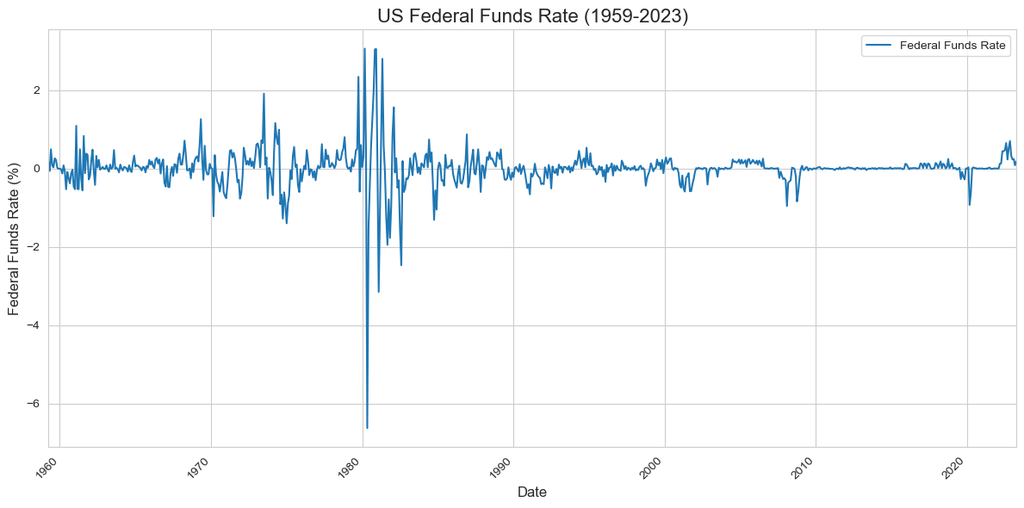

```
Average Federal Funds Rate: 0.00%
Minimum Federal Funds Rate: -6.63%
Maximum Federal Funds Rate: 3.06%
```

```python
# Create the plot
plt.figure(figsize=(12, 6))
sns.set_style("whitegrid")

# Plot the Federal Funds Rate
plt.plot(target.index, target['FEDFUNDS'], label='Federal Funds Rate')

# Customize the plot
plt.title('US Federal Funds Rate (1959-2023)', fontsize=16)
plt.xlabel('Date', fontsize=12)
plt.ylabel('Federal Funds Rate (%)', fontsize=12)
plt.legend()

# Rotate and align the tick labels so they look better
plt.gcf().autofmt_xdate(rotation=45, ha='right')

# Ensure x-axis shows full date range
plt.xlim(target.index.min(), target.index.max())

# Show the plot
plt.tight_layout()
plt.show()

# Print some basic statistics
print(f"Average Federal Funds Rate: {target['FEDFUNDS'].mean():.2f}%")
print(f"Minimum Federal Funds Rate: {target['FEDFUNDS'].min():.2f}%")
print(f"Maximum Federal Funds Rate: {target['FEDFUNDS'].max():.2f}%")
```

### B. Detect Multicollinearity

#### a. Correlation Matrix

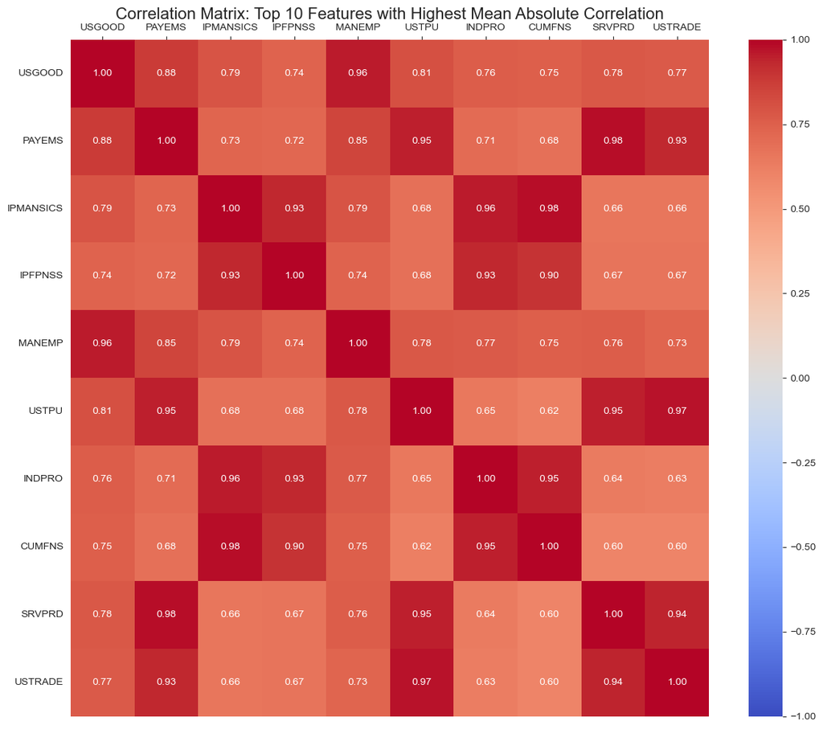

```python
# Calculate the correlation matrix for all features
corr_matrix = X.corr().round(2)

# Calculate the mean absolute correlation for each feature (positive & negative)
mean_abs_corr = corr_matrix.abs().mean().sort_values(ascending=False)

# Select top 10 features with highest mean absolute correlation
top_10_features = mean_abs_corr.nlargest(10).index

# Create a correlation matrix for these features
top_corr_matrix = corr_matrix.loc[top_10_features, top_10_features]

# Create the heatmap
plt.figure(figsize=(12, 10))
sns.heatmap(top_corr_matrix,
            annot=True,
            cmap='coolwarm',
            vmin=-1,
            vmax=1,
            center=0,
            fmt='.2f',
            xticklabels=top_10_features,
            yticklabels=top_10_features)

# Rotate the top labels
plt.xticks(rotation=45, ha='left')
plt.yticks(rotation=0)

# Move x-axis labels to the top
plt.tick_params(top=True, labeltop=True, bottom=False, labelbottom=False)

plt.title('Correlation Matrix: Top 10 Features with Highest Mean Absolute Correlation', fontsize=16, pad=20)
plt.tight_layout()
plt.show()
```

#### b. Variance Inflation Factor (VIF)

```
Top 20 features with highest VIF:
        Variables            VIF
47          HOUST  596589.963967
52         PERMIT  577744.348424
44  CES0600000007  140423.816786
46         AWHMAN  124488.070264
50         HOUSTS   98333.037641
55        PERMITS   70822.602190
56        PERMITW   31351.099778
51         HOUSTW   25799.888719
35         MANEMP   14736.820117
49        HOUSTMW   13967.106847
54       PERMITMW   12934.284761
36        DMANEMP    9064.488110
53       PERMITNE    6835.380672
48        HOUSTNE    5318.240586
31         PAYEMS    1400.718795
37       NDMANEMP    1333.444051
38         SRVPRD     985.777849
5          INDPRO     593.436434
89         AAAFFM     457.353119
90         BAAFFM     389.673487
```

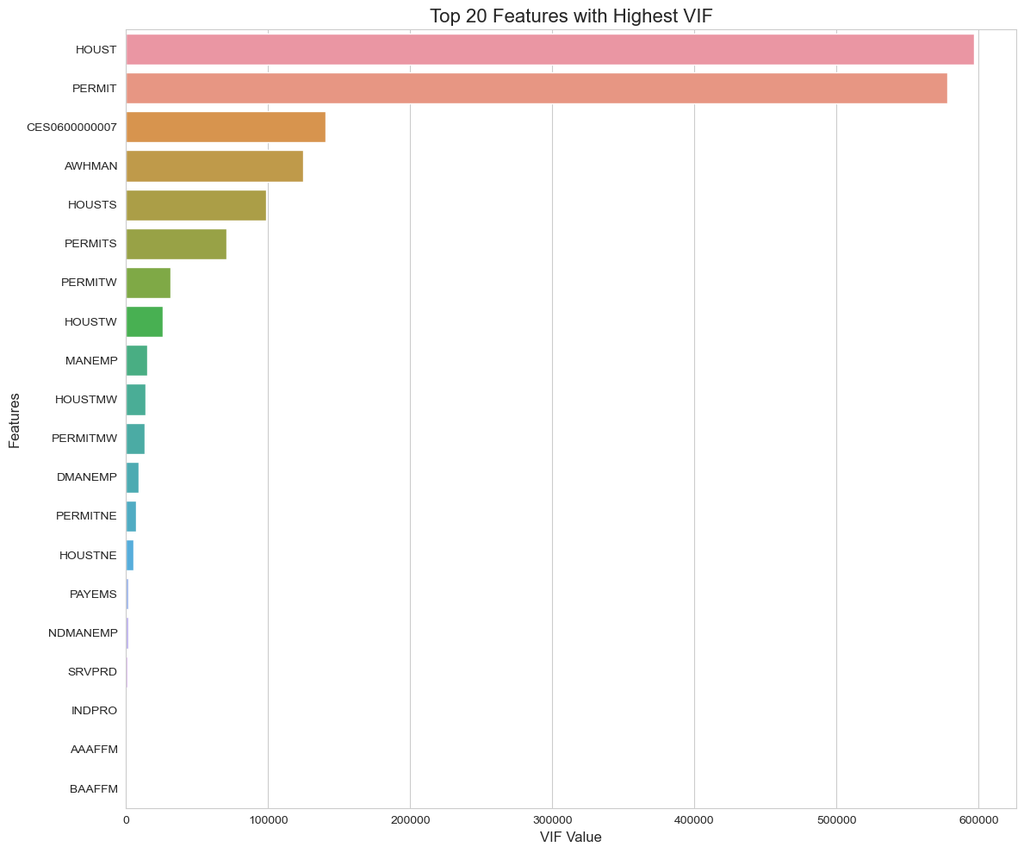

```python
def calculate_vif(X):
    # Calculating VIF
    vif = pd.DataFrame()
    vif["Variables"] = X.columns
    vif["VIF"] = [variance_inflation_factor(X.values, i) for i in range(X.shape[1])]
    return vif.sort_values('VIF', ascending=False)

# Calculate VIF
vif_data = calculate_vif(X)

# Display the top 20 features with highest VIF
print("Top 20 features with highest VIF:")
print(vif_data.head(20))

# Plotting VIF values
plt.figure(figsize=(12, 10))
sns.barplot(x='VIF', y='Variables', data=vif_data.head(20))
plt.title('Top 20 Features with Highest VIF', fontsize=16)
plt.xlabel('VIF Value', fontsize=12)
plt.ylabel('Features', fontsize=12)
plt.tight_layout()
plt.show()
```

The above indicates that there is multicollinearity issue. We could perform dimentionality reduction method as so to reduce the dimensions, as well as to see if multicollinearity issue could be solved.

## iii. Dimensionality Reduction

We would use OLS regression to be the baseline model, to compare the reduction performance with A. PCA, B. RFE C. SelectKBest. Note that since Regularisation model is just an extension of OLS, the pipeline with regularisation won't have OLS additionally

```python
import warnings
warnings.filterwarnings("ignore")
import time

# Sklearn
from sklearn import metrics
from sklearn.metrics import make_scorer
from sklearn.metrics import accuracy_score
from sklearn.metrics import mean_absolute_error
from sklearn.metrics import mean_squared_error
from sklearn.model_selection import train_test_split
from sklearn.metrics import r2_score, mean_squared_error

from sklearn import linear_model
from sklearn.linear_model import LinearRegression
from sklearn.linear_model import Ridge
from sklearn.linear_model import Lasso
from sklearn.linear_model import ElasticNet

from sklearn.pipeline import Pipeline
from sklearn.preprocessing import StandardScaler
from sklearn.preprocessing import MinMaxScaler
from sklearn.model_selection import TimeSeriesSplit
from sklearn.model_selection import RandomizedSearchCV
from sklearn.model_selection import GridSearchCV

from sklearn.decomposition import PCA
from sklearn.feature_selection import SelectKBest
from sklearn.feature_selection import RFE
```

```python
y = y["FEDFUNDS"] # From DF to Series
y
```

```
sasdate
1959-04-01    0.16
1959-05-01   -0.06
1959-06-01    0.49
1959-07-01    0.08
1959-08-01    0.03
              ...
2022-12-01    0.32
2023-01-01    0.23
2023-02-01    0.24
2023-03-01    0.08
2023-04-01    0.18
Name: FEDFUNDS, Length: 769, dtype: float64
```

### A. Baseline model without any dimensionality reduction

```python
train_split = 0.9
test_split = 0.1

n_train = int(train_split*len(X))
n_test = len(X)-n_train

print(n_train, n_test)
```

```
692 77
```

```python
# Pipeline

# Steps
steps = [('scaler', StandardScaler(copy=True, with_mean=True, with_std=True)),
         ('ols', LinearRegression())
              ]

pipeline = Pipeline(steps)
```

```python
start=time.time()

n_trains = n_train

n_records = n_train + n_test

y_test_list = []

y_pred_list = []

j = 0

for i in range(n_trains, n_records):

    X_train, X_test, y_train, y_test = X[j:i], X[i:i+1], y[j:i], y[i:i+1]

    model = pipeline.fit(X_train, y_train)

    y_pred = model.predict(X_test)

    y_pred_list.extend(y_pred)

    y_test_list.extend(y_test.values)

    j += 1

end=time.time()

ols_time = end-start
print("Running Time:", ols_time)
```

```
Running Time: 2.325706958770752
```

```python
result = pd.DataFrame({
    'IR_growth_Actual': [val[0] if isinstance(val, np.ndarray) else val for val in y_test_list],
    'IR_growth_Predicted': [val[0] if isinstance(val, np.ndarray) else val for val in y_pred_list]
})

result
```

|  | IR_growth_Actual | IR_growth_Predicted |
| --- | --- | --- |
| 0 | 0.13 | 0.322461 |
| 1 | 0.11 | -0.054048 |
| 2 | 0.01 | -0.032331 |
| 3 | 0.13 | -0.428634 |
| 4 | 0.11 | 0.120417 |
| ... | ... | ... |
| 72 | 0.32 | 0.376956 |
| 73 | 0.23 | 0.486321 |
| 74 | 0.24 | -0.152935 |
| 75 | 0.08 | 0.071684 |
| 76 | 0.18 | 0.256963 |

77 rows × 2 columns

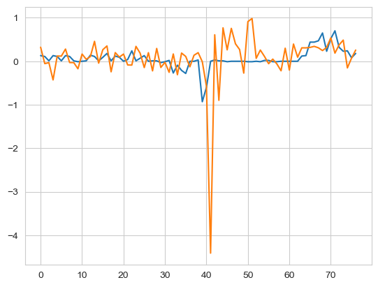

```python
result['IR_growth_Actual'].plot(label='Actual')
result['IR_growth_Predicted'].plot(label='Preducted')
```

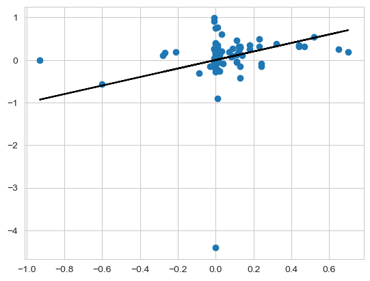

```python
plt.scatter(y_test_list, y_pred_list)
plt.plot(y_test_list, y_test_list,'k-') # identity line
```

```python
ols_mse = metrics.mean_squared_error(y_test_list, y_pred_list, squared=False)
ols_mse
```

```
0.6031261650287388
```

```python
ols_r2 = metrics.r2_score(y_test_list, y_pred_list)
ols_r2
```

```
-6.845652222608895
```

```python
model = "OLS"
r_square = ols_r2
mse = ols_mse
time = ols_time

ols_results = {
                'Model': model,
                'R-Squared': r_square,
                'MSE': mse,
                'Time': time
               }
```

```python
final_results = pd.DataFrame(columns = ['Model', 'R-Squared', 'MSE', 'Time'])
```

```python
final_results = pd.concat([final_results, pd.DataFrame([ols_results])], ignore_index=True)
final_results
```

|  | Model | R-Squared | MSE | Time |
| --- | --- | --- | --- | --- |
| 0 | OLS | -6.845652 | 0.603126 | 2.325707 |

### B. Baseline model with PCA

#### a. without regularisation

```python
# Standardize the features by taking μ = 0, σ = 1
for n_comp in [1,2,3,4,5,6,7,8,9,10,11,12,13,14,15,16,17,18,19,20,25,30,50,123]:

    steps_X = [('scaler', StandardScaler(copy=True, with_mean=True, with_std=True)),
               ('pca', PCA(n_components = n_comp, random_state=1))]

    pl_pca_X = Pipeline(steps_X)
    X_pca_model = pl_pca_X.fit(X)

    print('n_components:', n_comp, '  ', 'variance explained:', '%.3f' %X_pca_model.steps[1][1].explained_variance_ratio_.sum())
```

```
n_components: 1    variance explained: 0.188
n_components: 2    variance explained: 0.264
n_components: 3    variance explained: 0.331
n_components: 4    variance explained: 0.385
n_components: 5    variance explained: 0.436
n_components: 6    variance explained: 0.469
n_components: 7    variance explained: 0.497
n_components: 8    variance explained: 0.524
n_components: 9    variance explained: 0.545
n_components: 10    variance explained: 0.565
n_components: 11    variance explained: 0.583
n_components: 12    variance explained: 0.600
n_components: 13    variance explained: 0.617
n_components: 14    variance explained: 0.633
n_components: 15    variance explained: 0.648
n_components: 16    variance explained: 0.662
n_components: 17    variance explained: 0.675
n_components: 18    variance explained: 0.687
n_components: 19    variance explained: 0.699
n_components: 20    variance explained: 0.711
n_components: 25    variance explained: 0.760
n_components: 30    variance explained: 0.803
n_components: 50    variance explained: 0.918
n_components: 123    variance explained: 1.000
```

```python
train_split = 0.8
valid_split = 0.1
test_split = 0.1

n_train = int(train_split*len(X))
n_valid = int(valid_split*len(X))
n_test = len(X)-n_train-n_valid

print(n_train, n_valid, n_test)
```

```
615 76 78
```

```python
# pipeline
def pipeline(config):

    # unpack config
    n_comps = config

    # Steps
    steps = [('scaler', StandardScaler(copy=True, with_mean=True, with_std=True)),
             ('pca', PCA(n_components = n_comps, random_state=1)),
             ('ols', LinearRegression())
            ]

    pipeline = Pipeline(steps)

    return pipeline
```

```python
# Expanding Window
def walk_forward_validation(cfg):

    n_trains = n_train

    n_records = n_train + n_valid

    y_test_list = []

    y_pred_list = []

    j = 0

    for i in range(n_trains, n_records):

        X_train, X_test, y_train, y_test = X[j:i], X[i:i+1], y[j:i], y[i:i+1]

        model = pipeline(cfg).fit(X_train, y_train)

        y_pred = model.predict(X_test)

        y_pred_list.extend(y_pred)

        y_test_list.extend(y_test)

        j += 1

    score_rmse = metrics.mean_squared_error(y_test_list, y_pred_list, squared=False)

    print(' > %.3f' % score_rmse)

    return score_rmse
```

```python
# score a model, return None on failure
def repeat_evaluate(config, n_repeats=1):
    # convert config to a key
    key = str(config)
    # fit and evaluate the model n times
    scores = [walk_forward_validation(config) for _ in range(n_repeats)]
    # summarize score
    result = np.mean(scores)
    print('> Model[%s] %.3f' % (key, result))
    return (key, result)
```

```python
# grid search configs
def grid_search(cfg_list):
    # evaluate configs
    scores = [repeat_evaluate(cfg) for cfg in cfg_list]
    # sort configs by score_rmse, asc
    #scores.sort(key=lambda tup: tup[1])
    scores.sort(key=lambda tup: tup[1], reverse=True)
    return scores
```

```python
# create a list of configs to try
def model_configs():
    # define scope of configs

    n_comps = [3,4,5,7,9,10,12,14,16,18,20]

    # create configs
    configs = list()

    for k in n_comps:
        cfg = k
        configs.append(cfg)

    print('Total configs: %d' % len(configs))
    return configs
```

```python
# model configs
cfg_list = model_configs()
```

```
Total configs: 11
```

```python
cfg_list = model_configs()
# grid search
scores = grid_search(cfg_list)
print('done')
```

```
Total configs: 11
 > 0.093
> Model[3] 0.093
 > 0.115
> Model[4] 0.115
 > 0.116
> Model[5] 0.116
 > 0.152
> Model[7] 0.152
 > 0.152
> Model[9] 0.152
 > 0.153
> Model[10] 0.153
 > 0.157
> Model[12] 0.157
 > 0.161
> Model[14] 0.161
 > 0.155
> Model[16] 0.155
 > 0.153
> Model[18] 0.153
 > 0.156
> Model[20] 0.156
done
```

```python
scores
```

```
[('14', 0.16112405089233828),
 ('12', 0.15715985010753003),
 ('20', 0.15645541980069758),
 ('16', 0.1551841120972724),
 ('18', 0.15326665051063582),
 ('10', 0.15267484609401286),
 ('9', 0.1520399507581508),
 ('7', 0.1517842648958732),
 ('5', 0.1156884704243701),
 ('4', 0.1148839644807566),
 ('3', 0.09339526585004213)]
```

```python
# Pipeline

# Steps
steps_final = [('scaler', StandardScaler(copy=True, with_mean=True, with_std=True)),
               ('pca', PCA(n_components = 3, random_state=42)),
               ('ols', LinearRegression())
              ]

pipeline_final = Pipeline(steps_final)
```

```python
start=time.time()

n_trains = n_train + n_valid

n_records = n_train + n_valid + n_test

y_test_list = []

y_pred_list = []

j = 0

for i in range(n_trains, n_records):

    X_train, X_test, y_train, y_test = X[j:i], X[i:i+1], y[j:i], y[i:i+1]

    model = pipeline_final.fit(X_train, y_train)

    y_pred = model.predict(X_test)

    y_pred_list.extend(y_pred)

    y_test_list.extend(y_test)

    j += 1

end=time.time()

olspca_time = end-start
print("Running Time:", olspca_time)
```

```
Running Time: 0.660926103591919
```

```python
pd.options.display.max_rows=300
result = pd.DataFrame({'IR_growth_Actual': y[-n_test:], 'IR_growth_Predicted': y_pred_list}, columns=['IR_growth_Actual', 'IR_growth_Predicted'])
result
```

| sasdate | IR_growth_Actual | IR_growth_Predicted |
| --- | --- | --- |
| 2016-11-01 | 0.01 | -0.014526 |
| 2016-12-01 | 0.13 | -0.048581 |
| 2017-01-01 | 0.11 | 0.128701 |
| 2017-02-01 | 0.01 | -0.012541 |
| 2017-03-01 | 0.13 | -0.045692 |
| 2017-04-01 | 0.11 | 0.010696 |
| 2017-05-01 | 0.01 | 0.149953 |
| 2017-06-01 | 0.13 | -0.077557 |
| 2017-07-01 | 0.11 | 0.083693 |
| 2017-08-01 | 0.01 | -0.081190 |
| 2017-09-01 | -0.01 | -0.004719 |
| 2017-10-01 | 0.00 | 0.046901 |
| 2017-11-01 | 0.01 | 0.113416 |
| 2017-12-01 | 0.14 | 0.044781 |
| 2018-01-01 | 0.11 | 0.027759 |
| 2018-02-01 | 0.01 | 0.032782 |
| 2018-03-01 | 0.09 | 0.093434 |
| 2018-04-01 | 0.18 | 0.051919 |
| 2018-05-01 | 0.01 | 0.138402 |
| 2018-06-01 | 0.12 | -0.059446 |
| 2018-07-01 | 0.09 | 0.058921 |
| 2018-08-01 | 0.00 | -0.000091 |
| 2018-09-01 | 0.04 | 0.088509 |
| 2018-10-01 | 0.24 | 0.032252 |
| 2018-11-01 | 0.01 | -0.058434 |
| 2018-12-01 | 0.07 | -0.059237 |
| 2019-01-01 | 0.13 | -0.088330 |
| 2019-02-01 | 0.00 | -0.107368 |
| 2019-03-01 | 0.01 | -0.064763 |
| 2019-04-01 | 0.01 | -0.000330 |
| 2019-05-01 | -0.03 | -0.110896 |
| 2019-06-01 | -0.01 | -0.093591 |
| 2019-07-01 | 0.02 | -0.063477 |
| 2019-08-01 | -0.27 | -0.063037 |
| 2019-09-01 | -0.09 | 0.008069 |
| 2019-10-01 | -0.21 | -0.073715 |
| 2019-11-01 | -0.28 | -0.164707 |
| 2019-12-01 | 0.00 | 0.086619 |
| 2020-01-01 | 0.00 | -0.064425 |
| 2020-02-01 | 0.03 | -0.041829 |
| 2020-03-01 | -0.93 | -0.001556 |
| 2020-04-01 | -0.60 | -1.593331 |
| 2020-05-01 | 0.00 | -6.170149 |
| 2020-06-01 | 0.03 | 0.166427 |
| 2020-07-01 | 0.01 | 0.464712 |
| 2020-08-01 | 0.01 | 0.116598 |
| 2020-09-01 | -0.01 | 0.129616 |
| 2020-10-01 | 0.00 | 0.029899 |
| 2020-11-01 | 0.00 | 0.066370 |
| 2020-12-01 | 0.00 | 0.016673 |
| 2021-01-01 | 0.00 | 0.038927 |
| 2021-02-01 | -0.01 | 0.072079 |
| 2021-03-01 | -0.01 | -0.112687 |
| 2021-04-01 | 0.00 | 0.174432 |
| 2021-05-01 | -0.01 | 0.013291 |
| 2021-06-01 | 0.02 | 0.056861 |
| 2021-07-01 | 0.02 | 0.032200 |
| 2021-08-01 | -0.01 | 0.077678 |
| 2021-09-01 | -0.01 | 0.044574 |
| 2021-10-01 | 0.00 | 0.025170 |
| 2021-11-01 | 0.00 | 0.106223 |
| 2021-12-01 | 0.00 | 0.090442 |
| 2022-01-01 | 0.00 | 0.093026 |
| 2022-02-01 | 0.00 | 0.060154 |
| 2022-03-01 | 0.12 | 0.125745 |
| 2022-04-01 | 0.13 | 0.109659 |
| 2022-05-01 | 0.44 | 0.061387 |
| 2022-06-01 | 0.44 | 0.011184 |
| 2022-07-01 | 0.47 | 0.008708 |
| 2022-08-01 | 0.65 | 0.050362 |
| 2022-09-01 | 0.23 | -0.025120 |
| 2022-10-01 | 0.52 | 0.069648 |
| 2022-11-01 | 0.70 | 0.018333 |
| 2022-12-01 | 0.32 | -0.041168 |
| 2023-01-01 | 0.23 | -0.042402 |
| 2023-02-01 | 0.24 | 0.001010 |
| 2023-03-01 | 0.08 | 0.018628 |
| 2023-04-01 | 0.18 | 0.012954 |

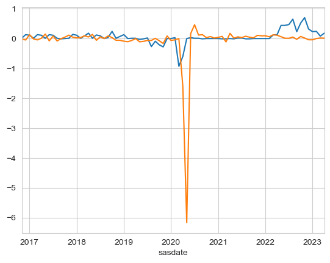

```python
result['IR_growth_Actual'].plot(label='Actual')
result['IR_growth_Predicted'].plot(label='Preducted')
```

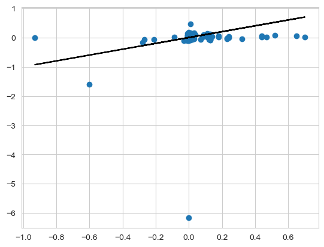

```python
plt.scatter(y_test_list, y_pred_list)
plt.plot(y_test_list, y_test_list,'k-') # identity line
```

```python
olspca_mse = metrics.mean_squared_error(y_test_list, y_pred_list, squared=False)
olspca_mse
```

```
0.7398554782171923
```

```python
olspca_r2 = metrics.r2_score(y_test_list, y_pred_list)
olspca_r2
```

```
-10.952001051877366
```

```python
model = "OLS with PCA"
r_square = olspca_r2
mse = olspca_mse
time = olspca_time

olspca_results = {
                    'Model': model,
                    'R-Squared': r_square,
                    'MSE': mse,
                    'Time': time
                  }
```

```python
final_results = pd.concat([final_results, pd.DataFrame([olspca_results])], ignore_index=True)
final_results
```

|  | Model | R-Squared | MSE | Time |
| --- | --- | --- | --- | --- |
| 0 | OLS | -6.845652 | 0.603126 | 2.325707 |
| 1 | OLS with PCA | -10.952001 | 0.739855 | 0.660926 |